# Conjoint Analysis for Product Development

Sebuah Learning Forum

Market Research Dept.

30 Maret 2020

# *Conjoint Analysis*

## Definisi

> *Conjoint analysis is a survey-based statistical technique used in market research that helps determine how people value different attributes (feature, function, benefits) that make up an individual product or service.*

## Sejarah

*Conjoint analysis originated in mathematical psychology and was developed by marketing professor Paul E. Green at the Wharton School of the University of Pennsylvania. Other prominent conjoint analysis pioneers include professor V. “Seenu” Srinivasan of Stanford University who developed a linear programming (LINMAP) procedure for rank ordered data as well as a self-explicated approach, and Jordan Louviere (University of Iowa) who invented and developed choice-based approaches to conjoint analysis and related techniques such as best–worst scaling.*

## Penggunaan

*Conjoint Analysis* kerap digunakan dalam bidang *new product/service development*. Salah satu keunggulannya adalah menghitung seberapa penting suatu *attribute* dengan *indirect question* menggunakan konsep **ortogonalitas** yang ada di aljabar.

[*Maxis*](https://www.maxis.com.my/en/about-maxis/) merupakan salah satu *provider* telekomunikasi terbesar di Malaysia. Pada medio 2011, Maxis hendak membuat beberapa *starter pack* yang ditujukan khusus kepada TKI yang bekerja di Malaysia. Mereka hendak memilah dan memilih *features* apa saja yang sebaiknya dimasukkan ke dalam *starter pack* tersebut.

Pada waktu itu, pemilihan *attributes* dan *levels* yang digunakan berasal dari *focus group discussion*.

## Istilah yang Perlu Diketahui

Ada dua istilah yang sudah saya sebut beberapa kali, yakni:

1. *Attributes* dan
2. *Levels*.

### Membedakan *Attributes* dan *Levels*

Misalkan:

> **Nutrifood** berencana untuk meluncurkan *mie instan* varian terbaru di akhir tahun ini. Namun mereka masih bingung kira-kira faktor apa saja yang harus ada di *mie instan* tersebut.

Mereka sudah *list* beberapa alternatif pilihan sebagai berikut:

1. Warna *mie*, pilihannya:
   - Kuning
   - Hijau
   - Merah
2. Rasa *mie*, pilihannya:
   - Soto
   - Kari Ayam
   - Goreng Jawa
3. Klaim *mie*, pilihannya:
   - *Less salt*
   - *No msg*
   - *Less fat*

Faktor `warna`, `rasa` dan `klaim` disebut *attributes*.

Sedangkan pilihan-pilihan yang ada di masing-masing *attributes* (misal `kuning`, `hijau`, …, `no msg`, `less fat`) disebut *levels*.

### Perbedaan dengan Survey Biasa

Jika kita melakukan **survey biasa**, hal yang paling sering terjadi adalah memberikan pertanyaan langsung (*direct question*) kepada responden terkait seberapa penting masing-masing *attributes* dan *levels* mana yang mereka pilih.

Contohnya sebagai berikut:

1. Dalam memilih suatu *mie instan*, dari ketiga faktor berikut ini: warna, rasa, dan klaim. Urutkan dari aspek yang **paling penting** ke aspek yang paling **tidak penting**!
   - Urutan 1:
   - Urutan 2:
   - Urutan 3:
2. Warna *mie instan* apa yang Anda sukai? (pilih salah satu)
   - Kuning
   - Hijau
   - Merah
3. Rasa *mie instan* apa yang Anda sukai? (pilih salah satu)
   - Soto
   - Kari Ayam
   - Goreng Jawa
4. Klaim *mie instan* apa yang Anda sukai? (pilih salah satu)
   - *Less salt*
   - *No msg*
   - *Less fat*

Jika kita menggunakan *Conjoint Analysis*, kita tidak akan bertanya *direct* kepada responden seperti pada cara sebelumnya. Lantas bagaimana caranya?

> *Kita akan memberikan beberapa alternatif pilihan produk untuk kemudian dipilih oleh responden.*

Responden bisa diminta untuk:

1. Memberikan *ranking* (mengurutkan) alternatif produk mana yang **paling disukai** sampai yang **tidak disukai**.
2. Memberikan *rating* (nilai) setiap alternatif produk yang ditanyakan.
3. Memilih **satu saja alternatif produk** yang paling disukai.

Pertanyaannya adalah:

> *Bagaimana caranya kita menentukan beberapa alternatif pilihan produk yang hendak ditanyakan?*

# Penentuan Alternatif Pilihan

## Semua Kombinasi yang Mungkin

Perhatikan bahwa kita memiliki 3 *level* di *attribute* `warna`, 3 *level* di *atribute* `rasa`, dan 3 *level* di *atribute* `klaim`.

Oleh karena itu, ada $3 * 3 * 3 = 27$ alternatif pilihan produk yang bisa ditawarkan sebagai berikut:

```r
experiment %>%
  mutate(Alternatif = 1:nrow(experiment)) %>%
  relocate(Alternatif,.before = Var1) %>%
  rename(Warna = Var1,
         Rasa = Var2,
         Klaim = Var3) %>%
  knitr::kable()
```

| Alternatif | Warna | Rasa | Klaim |
| --- | --- | --- | --- |
| 1 | kuning | soto | less salt |
| 2 | hijau | soto | less salt |
| 3 | merah | soto | less salt |
| 4 | kuning | kari ayam | less salt |
| 5 | hijau | kari ayam | less salt |
| 6 | merah | kari ayam | less salt |
| 7 | kuning | goreng jawa | less salt |
| 8 | hijau | goreng jawa | less salt |
| 9 | merah | goreng jawa | less salt |
| 10 | kuning | soto | no msg |
| 11 | hijau | soto | no msg |
| 12 | merah | soto | no msg |
| 13 | kuning | kari ayam | no msg |
| 14 | hijau | kari ayam | no msg |
| 15 | merah | kari ayam | no msg |
| 16 | kuning | goreng jawa | no msg |
| 17 | hijau | goreng jawa | no msg |
| 18 | merah | goreng jawa | no msg |
| 19 | kuning | soto | less fat |
| 20 | hijau | soto | less fat |
| 21 | merah | soto | less fat |
| 22 | kuning | kari ayam | less fat |
| 23 | hijau | kari ayam | less fat |
| 24 | merah | kari ayam | less fat |
| 25 | kuning | goreng jawa | less fat |
| 26 | hijau | goreng jawa | less fat |
| 27 | merah | goreng jawa | less fat |

Masalah yang timbul adalah:

> *Kita tidak mungkin menawarkan* 27 *buah alternatif produk kepada responden.*

## *Orthogonalitas* dalam Aljabar Linear

Secara simpel, ortogonal berarti **tegak lurus**.

Di dalam aljabar linear, dua *vector* disebut tegak lurus jika *cosine* dari sudut yang terbentuk (misal saya tuliskan sebagai $\theta$), $cos(\theta) = 0$.

Berapa nilai $\theta$?

Ilustrasi bidang kartesian:

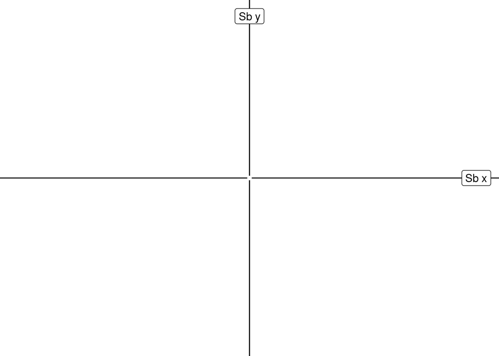

```r
data.frame(x = c(-10:10),
           y = c(-10:10)) %>%
  ggplot(aes(x = x,
             y = y)) +
  geom_vline(xintercept = 0) +
  geom_hline(yintercept = 0) +
  theme_void() +
  geom_point(color = "white") +
  annotate("label",x = 10,y=0,label = "Sb x") +
  annotate("label",x = 0,y=10,label = "Sb y")
```

Apa kegunaan *orthogonal*?

## Basis *Vector*

Salah satu kegunaan *vector orthogonal* adalah bisa dijadikan basis dalam suatu dimensi.

> *Apa itu basis?*

Misal $\bar{u}$ dan $\bar{v}$ adalah *vector* basis di bidang dimensi `2`, maka untuk setiap $\bar{z}$ sembarang *vector* di bidang dimensi dua bisa dituliskan sebagai fungsi dari $\bar{u}$ dan $\bar{v}$.

$$\bar{z} = f(\bar{u},\bar{v})$$

### Quis: *Vector* Basis

Misalkan saya memiliki sebuah bidang dimensi 2.

1. Ada berapa *vector* basis yang ada?
2. Apa saja vector basis yang ada?

### Jawaban

1. Ada dua *vector* basis oleh karena itu disebut **dimensi 2**. Banyak dimensi menunjukkan berapa banyak *vector* basis.
2. *Vector* basis yang ada:
   - $(1,0)$
   - $(0,1)$

Misalkan ada suatu *vector* sembarang di dimensi dua sebagai berikut $(a,b)$, maka dia bisa dituliskan sebagai:

$$(a,b) = a(1,0) + b(0,1)$$

Lantas apa hubungannya dengan *Conjoint*?

# *Factorial Design*

Dalam *conjoint* ada istilah yang disebut dengan *factorial design*, yakni sebagian alternatif dari keseluruhan alternatif yang mungkin muncul dari kombinasi semua *attributes* dan *levels*.

Penentuannya adalah dengan menggunakan prinsip *orthogonalitas*:

> Hanya berisi basis *vector* sehingga bisa digunakan **untuk membangun** semua kombinasi yang mungkin.

## Alternatif Mie Instan yang Ditanyakan ke Responden

Berikut adalah `8` alternatif mie instan yang dinilai merupakan basis *orthogonal* hasil *output* dari **R**:

```r
factdesign %>%
  rename(Warna = Var1,
         Rasa = Var2,
         Klaim = Var3) %>%
  knitr::kable(caption = "Alternatif",align = "c")
```

Alternatif

|  | Warna | Rasa | Klaim |
| --- | --- | --- | --- |
| 2 | hijau | soto | less salt |
| 6 | merah | kari ayam | less salt |
| 7 | kuning | goreng jawa | less salt |
| 12 | merah | soto | no msg |
| 13 | kuning | kari ayam | no msg |
| 17 | hijau | goreng jawa | no msg |
| 19 | kuning | soto | less fat |
| 27 | merah | goreng jawa | less fat |

## Pembuktian *orthogonalitas*

*Orthogonalitas* bisa dibuktikan dengan dua cara, yakni dengan membuat matriks kovariansi dan matriks korelasi. Jika kita mendapatkan hasil antar variabel tidak ditemukan kovriansi dan korelasi, maka bisa dibilang bahwa `8` alternatif tersebut adalah basis *orthogonal*.

### Matriks Kovariansi

```r
knitr::kable(round(cov(prof),1))
```

|  | Warna | Rasa | Klaim_unggulan |
| --- | --- | --- | --- |
| Warna | 0.9 | 0.0 | 0.0 |
| Rasa | 0.0 | 0.9 | 0.0 |
| Klaim_unggulan | 0.0 | 0.0 | 0.7 |

### Matriks Korelasi

```r
knitr::kable(round(cor(prof),1))
```

|  | Warna | Rasa | Klaim_unggulan |
| --- | --- | --- | --- |
| Warna | 1 | 0 | 0 |
| Rasa | 0 | 1 | 0 |
| Klaim_unggulan | 0 | 0 | 1 |

Terlihat bahwa `8` alternatif adalah basis *orthogonal*.

# Hasil Survey

Kemarin saya telah menyebar survey untuk diisi. Rekan-rekan disuruh untuk memberikan *rating* 1 - 6 kepada `8` alternatif mie instan. Urutan `8` alternatif mie instan dibuat *random* per responden.

## Data Mentah

Berikut adalah data mentah yang saya dapatkan:

```r
data = read.csv("hasil survey.csv")
data = data %>% janitor::clean_names()
colnames(data)[7:14] = paste0("alt",1:8)

data = data %>% select(nama_kamu,contains("alt"))
data_new = data.frame(t(data))
colnames(data_new) = data_new[1,]
data_new = data_new[-1,]

d1 =
  factdesign %>%
  rename(Warna = Var1,
         Rasa = Var2,
         Klaim = Var3)

data.frame(d1,data_new) %>% knitr::kable(align = "c",caption = "Hasil Survey")
```

Hasil Survey

|  | Warna | Rasa | Klaim | Nico | Liancing | Yanti | Ganang.Dino.Utama | Ucup | Lenny | Charissa.L | Astri | Fahmi.Rizaldi | rendy | Budiyanto | Claire | pebe | Feli | Amel |
| --- | --- | --- | --- | --- | --- | --- | --- | --- | --- | --- | --- | --- | --- | --- | --- | --- | --- | --- |
| 2 | hijau | soto | less salt | 4 | 4 | 5 | 3 | 5 | 5 | 4 | 4 | 5 | 2 | 4 | 4 | 4 | 3 | 3 |
| 6 | merah | kari ayam | less salt | 6 | 3 | 5 | 5 | 4 | 3 | 3 | 2 | 3 | 5 | 5 | 3 | 3 | 3 | 6 |
| 7 | kuning | goreng jawa | less salt | 5 | 5 | 5 | 5 | 4 | 2 | 4 | 3 | 4 | 4 | 5 | 2 | 4 | 3 | 3 |
| 12 | merah | soto | no msg | 3 | 4 | 5 | 3 | 4 | 5 | 4 | 2 | 3 | 2 | 4 | 1 | 5 | 2 | 5 |
| 13 | kuning | kari ayam | no msg | 3 | 3 | 5 | 5 | 2 | 2 | 3 | 6 | 4 | 5 | 5 | 3 | 5 | 2 | 6 |
| 17 | hijau | goreng jawa | no msg | 3 | 5 | 5 | 6 | 3 | 3 | 4 | 5 | 3 | 5 | 5 | 2 | 4 | 2 | 3 |
| 19 | kuning | soto | less fat | 4 | 4 | 5 | 3 | 6 | 4 | 5 | 6 | 5 | 2 | 5 | 5 | 3 | 4 | 5 |
| 27 | merah | goreng jawa | less fat | 5 | 5 | 5 | 5 | 5 | 3 | 5 | 3 | 6 | 5 | 4 | 2 | 3 | 4 | 5 |

## Analisa Overall

Berikut adalah hasil analisa *overall*.

```r
library(conjoint)
Conjoint(y=data_new, x=prof, z=case_level)
```

```
##
## Call:
## lm(formula = frml)
##
## Residuals:
##     Min      1Q  Median      3Q     Max
## -2,7333 -0,8667  0,1333  1,0000  2,3333
##
## Coefficients:
##                           Estimate Std. Error t value Pr(>|t|)
## (Intercept)                3,95556    0,12621  31,341   <2e-16 ***
## factor(x$Warna)1           0,06667    0,16294   0,409    0,683
## factor(x$Warna)2          -0,08889    0,20610  -0,431    0,667
## factor(x$Rasa)1           -0,20000    0,16294  -1,227    0,222
## factor(x$Rasa)2           -0,04444    0,20610  -0,216    0,830
## factor(x$Klaim_unggulan)1  0,06667    0,16294   0,409    0,683
## factor(x$Klaim_unggulan)2 -0,11111    0,16294  -0,682    0,497
## ---
## Signif. codes:  0 '***' 0,001 '**' 0,01 '*' 0,05 '.' 0,1 ' ' 1
##
## Residual standard error: 1,197 on 113 degrees of freedom
## Multiple R-squared:  0,03495,    Adjusted R-squared:  -0,01629
## F-statistic: 0,682 on 6 and 113 DF,  p-value: 0,6645
```

```
## [1] "Part worths (utilities) of levels (model parameters for whole sample):"
##         levnms    utls
## 1    intercept  3,9556
## 2       kuning  0,0667
## 3        hijau -0,0889
## 4        merah  0,0222
## 5         soto    -0,2
## 6    kari ayam -0,0444
## 7  goreng jawa  0,2444
## 8    less salt  0,0667
## 9       no msg -0,1111
## 10    less fat  0,0444
## [1] "Average importance of factors (attributes):"
## [1] 36,00 31,54 32,47
## [1] Sum of average importance:  100,01
## [1] "Chart of average factors importance"
```

### *Attributes Importance*

Dari analisa di atas, kita dapatkan *attributes importance* sebagai berikut:

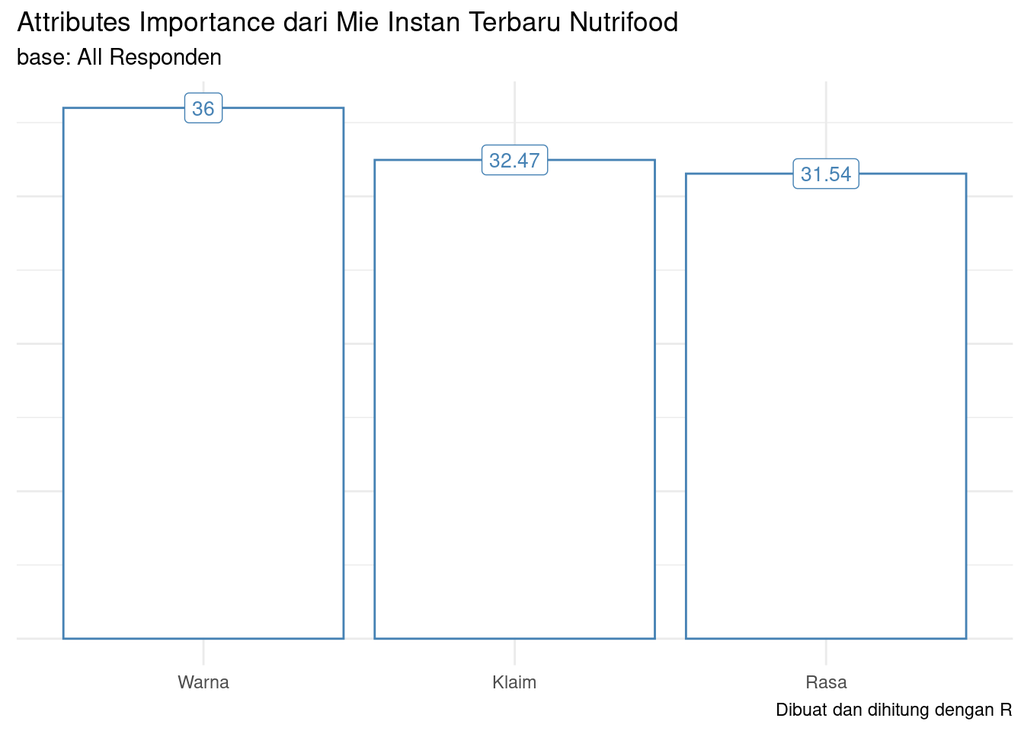

```r
att =
  data.frame(att = c("Warna","Rasa","Klaim"),
           imp = c(36,31.54,32.47))

att %>%
  ggplot(aes(x = reorder(att,-imp),
             y = imp)) +
  geom_col(color = "steelblue",
           fill = "white") +
  geom_label(aes(label = imp),
             color = "steelblue",
             fill = "white",
             size = 3.5) +
  theme_minimal() +
  labs(title = "Attributes Importance dari Mie Instan Terbaru Nutrifood",
       subtitle = "base: All Responden",
       caption = "Dibuat dan dihitung dengan R") +
  theme(axis.title = element_blank(),
        axis.text.y = element_blank())
```

### *Levels Utilities*

Berikut adalah nilai *utilities* dari masing-masing *levels*:

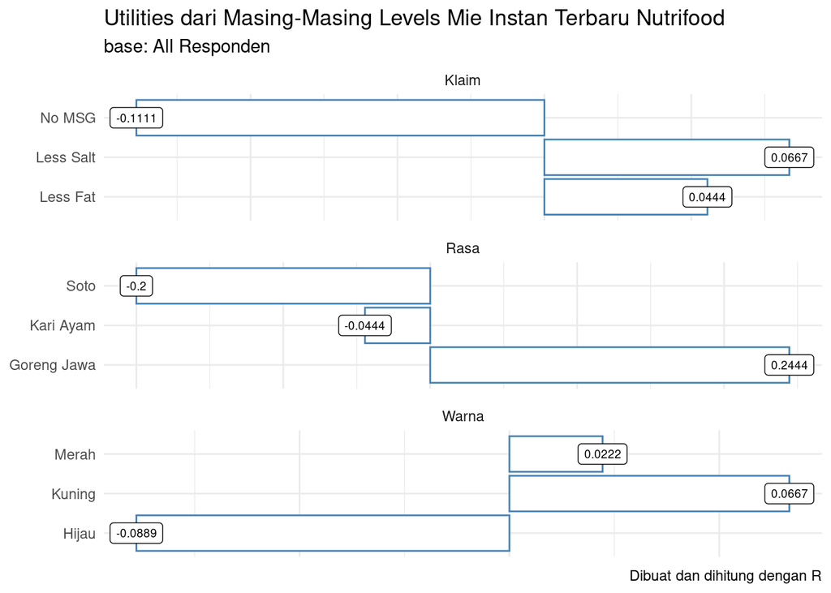

```r
lev =
  data.frame(atr = c(rep("Warna",3),
                     rep("Rasa",3),
                     rep("Klaim",3)),
             level = c("Kuning","Hijau","Merah",
                       "Soto","Kari Ayam","Goreng Jawa",
                       "Less Salt","No MSG","Less Fat"),
             utils = c(.0667,-.0889,.0222,
                       -.2,-.0444,.2444,
                       .0667,-.1111,.0444)
             )

lev %>%
  ggplot(aes(y = level,
             x = utils)) +
  geom_col(color = "steelblue",
           fill = "white") +
  geom_label(aes(label = utils),
             size = 2.5) +
  facet_wrap(~atr,ncol = 1,scales = "free") +
  theme_minimal() +
  labs(title = "Utilities dari Masing-Masing Levels Mie Instan Terbaru Nutrifood",
       subtitle = "base: All Responden",
       caption = "Dibuat dan dihitung dengan R") +
  theme(axis.title = element_blank(),
        axis.text.x = element_blank())
```

### *Summary*

Dari kedua grafik di atas, kita telah mendapatkan *insights* bahwa:

1. Ketiga *attributes* memiliki skala kepentingan yang hampir sama bagi *overall* responden.
2. Produk mie instan terbaik bisa didapatkan dengan memilih *levels* yang memiliki nilai *utilities* tertinggi.

## *What’s Next*

Selain melakukan analisa untuk *overall* responden, kita bisa melakukan analisa untuk masing-masing individual responden atau beberapa kelompok responden. Sebagai contoh:

1. Apakah ada perbedaan *attributes importance* dari responden wanita dan pria?
2. Apakah ada perbedaan nilai *utilities* dari setiap *levels* untuk masing-masing responden?

### Analisa Individual

Sekarang saya akan melakukan analisa individual sebagai berikut:

#### Pebe

```r
Conjoint(y=data_new[13], x=prof, z=case_level)
```

```
##
## Call:
## lm(formula = frml)
##
## Residuals:
##          1          2          3          4          5          6          7
##  3,333e-01 -3,333e-01 -2,776e-17  4,163e-17  3,333e-01 -3,333e-01 -3,333e-01
##          8
##  3,333e-01
##
## Coefficients:
##                             Estimate Std. Error t value Pr(>|t|)
## (Intercept)                3,667e+00  3,333e-01  11,000   0,0577 .
## factor(x$Warna)1           3,333e-01  4,303e-01   0,775   0,5804
## factor(x$Warna)2          -3,333e-01  5,443e-01  -0,612   0,6502
## factor(x$Rasa)1            3,333e-01  4,303e-01   0,775   0,5804
## factor(x$Rasa)2           -3,333e-01  5,443e-01  -0,612   0,6502
## factor(x$Klaim_unggulan)1 -4,587e-16  4,303e-01   0,000   1,0000
## factor(x$Klaim_unggulan)2  1,000e+00  4,303e-01   2,324   0,2587
## ---
## Signif. codes:  0 '***' 0,001 '**' 0,01 '*' 0,05 '.' 0,1 ' ' 1
##
## Residual standard error: 0,8165 on 1 degrees of freedom
## Multiple R-squared:  0,8632, Adjusted R-squared:  0,04274
## F-statistic: 1,052 on 6 and 1 DF,  p-value: 0,6328
```

```
## [1] "Part worths (utilities) of levels (model parameters for whole sample):"
##         levnms    utls
## 1    intercept  3,6667
## 2       kuning  0,3333
## 3        hijau -0,3333
## 4        merah       0
## 5         soto  0,3333
## 6    kari ayam -0,3333
## 7  goreng jawa       0
## 8    less salt       0
## 9       no msg       1
## 10    less fat      -1
## [1] "Average importance of factors (attributes):"
## [1] 20 20 60
## [1] Sum of average importance:  100
## [1] "Chart of average factors importance"
```

#### Lian Cing

```r
Conjoint(y=data_new[2], x=prof, z=case_level)
```

```
##
## Call:
## lm(formula = frml)
##
## Residuals:
##          1          2          3          4          5          6          7
## -4,124e-16  4,124e-16 -1,233e-31 -1,233e-31 -4,124e-16  4,124e-16  4,124e-16
##          8
## -4,124e-16
##
## Coefficients:
##                             Estimate Std. Error    t value Pr(>|t|)
## (Intercept)                4,000e+00  4,124e-16  9,698e+15  < 2e-16 ***
## factor(x$Warna)1           4,835e-16  5,325e-16  9,080e-01    0,531
## factor(x$Warna)2          -9,669e-16  6,735e-16 -1,436e+00    0,387
## factor(x$Rasa)1           -2,719e-16  5,325e-16 -5,110e-01    0,699
## factor(x$Rasa)2           -1,000e+00  6,735e-16 -1,485e+15 4,29e-16 ***
## factor(x$Klaim_unggulan)1 -2,511e-16  5,325e-16 -4,720e-01    0,719
## factor(x$Klaim_unggulan)2  2,433e-16  5,325e-16  4,570e-01    0,727
## ---
## Signif. codes:  0 '***' 0,001 '**' 0,01 '*' 0,05 '.' 0,1 ' ' 1
##
## Residual standard error: 1,01e-15 on 1 degrees of freedom
## Multiple R-squared:      1,  Adjusted R-squared:      1
## F-statistic: 7,961e+29 on 6 and 1 DF,  p-value: 8,579e-16
```

```
## [1] "Part worths (utilities) of levels (model parameters for whole sample):"
##         levnms utls
## 1    intercept    4
## 2       kuning    0
## 3        hijau    0
## 4        merah    0
## 5         soto    0
## 6    kari ayam   -1
## 7  goreng jawa    1
## 8    less salt    0
## 9       no msg    0
## 10    less fat    0
## [1] "Average importance of factors (attributes):"
## [1]   0 100   0
## [1] Sum of average importance:  100
## [1] "Chart of average factors importance"
```

#### Ucup

```r
Conjoint(y=data_new[5], x=prof, z=case_level)
```

```
##
## Call:
## lm(formula = frml)
##
## Residuals:
##          1          2          3          4          5          6          7
## -1,667e-01  1,667e-01 -1,388e-17 -3,469e-17 -1,667e-01  1,667e-01  1,667e-01
##          8
## -1,667e-01
##
## Coefficients:
##                             Estimate Std. Error t value Pr(>|t|)
## (Intercept)                4,167e+00  1,667e-01  25,000   0,0255 *
## factor(x$Warna)1          -1,667e-01  2,152e-01  -0,775   0,5804
## factor(x$Warna)2           4,029e-16  2,722e-01   0,000   1,0000
## factor(x$Rasa)1            8,333e-01  2,152e-01   3,873   0,1609
## factor(x$Rasa)2           -6,667e-01  2,722e-01  -2,449   0,2468
## factor(x$Klaim_unggulan)1  1,667e-01  2,152e-01   0,775   0,5804
## factor(x$Klaim_unggulan)2 -1,167e+00  2,152e-01  -5,422   0,1161
## ---
## Signif. codes:  0 '***' 0,001 '**' 0,01 '*' 0,05 '.' 0,1 ' ' 1
##
## Residual standard error: 0,4082 on 1 degrees of freedom
## Multiple R-squared:  0,9847, Adjusted R-squared:  0,8927
## F-statistic: 10,71 on 6 and 1 DF,  p-value: 0,2298
```

```
## [1] "Part worths (utilities) of levels (model parameters for whole sample):"
##         levnms    utls
## 1    intercept  4,1667
## 2       kuning -0,1667
## 3        hijau       0
## 4        merah  0,1667
## 5         soto  0,8333
## 6    kari ayam -0,6667
## 7  goreng jawa -0,1667
## 8    less salt  0,1667
## 9       no msg -1,1667
## 10    less fat       1
## [1] "Average importance of factors (attributes):"
## [1]  8,33 37,50 54,17
## [1] Sum of average importance:  100
## [1] "Chart of average factors importance"
```

#### Fahmi

```r
Conjoint(y=data_new[9], x=prof, z=case_level)
```

```
##
## Call:
## lm(formula = frml)
##
## Residuals:
##          1          2          3          4          5          6          7
##  6,667e-01 -6,667e-01  1,388e-16  1,943e-16  6,667e-01 -6,667e-01 -6,667e-01
##          8
##  6,667e-01
##
## Coefficients:
##                             Estimate Std. Error t value Pr(>|t|)
## (Intercept)                4,333e+00  6,667e-01   6,500   0,0972 .
## factor(x$Warna)1           3,626e-16  8,607e-01   0,000   1,0000
## factor(x$Warna)2           3,333e-01  1,089e+00   0,306   0,8108
## factor(x$Rasa)1           -6,821e-17  8,607e-01   0,000   1,0000
## factor(x$Rasa)2           -2,564e-16  1,089e+00   0,000   1,0000
## factor(x$Klaim_unggulan)1 -3,333e-01  8,607e-01  -0,387   0,7648
## factor(x$Klaim_unggulan)2 -1,000e+00  8,607e-01  -1,162   0,4524
## ---
## Signif. codes:  0 '***' 0,001 '**' 0,01 '*' 0,05 '.' 0,1 ' ' 1
##
## Residual standard error: 1,633 on 1 degrees of freedom
## Multiple R-squared:  0,6995, Adjusted R-squared:  -1,103
## F-statistic: 0,388 on 6 and 1 DF,  p-value: 0,8405
```

```
## [1] "Part worths (utilities) of levels (model parameters for whole sample):"
##         levnms    utls
## 1    intercept  4,3333
## 2       kuning       0
## 3        hijau  0,3333
## 4        merah -0,3333
## 5         soto       0
## 6    kari ayam       0
## 7  goreng jawa       0
## 8    less salt -0,3333
## 9       no msg      -1
## 10    less fat  1,3333
## [1] "Average importance of factors (attributes):"
## [1] 22,22  0,00 77,78
## [1] Sum of average importance:  100
## [1] "Chart of average factors importance"
```

#### Charissa

```r
Conjoint(y=data_new[7], x=prof, z=case_level)
```

```
##
## Call:
## lm(formula = frml)
##
## Residuals:
##          1          2          3          4          5          6          7
## -4,419e-16  4,419e-16 -9,861e-32 -2,465e-32 -4,419e-16  4,419e-16  4,419e-16
##          8
## -4,419e-16
##
## Coefficients:
##                             Estimate Std. Error    t value Pr(>|t|)
## (Intercept)                4,000e+00  4,419e-16  9,052e+15  < 2e-16 ***
## factor(x$Warna)1           5,842e-16  5,705e-16  1,024e+00    0,492
## factor(x$Warna)2          -1,047e-15  7,216e-16 -1,452e+00    0,384
## factor(x$Rasa)1            3,333e-01  5,705e-16  5,843e+14 1,09e-15 ***
## factor(x$Rasa)2           -6,667e-01  7,216e-16 -9,238e+14 6,89e-16 ***
## factor(x$Klaim_unggulan)1 -3,333e-01  5,705e-16 -5,843e+14 1,09e-15 ***
## factor(x$Klaim_unggulan)2 -3,333e-01  5,705e-16 -5,843e+14 1,09e-15 ***
## ---
## Signif. codes:  0 '***' 0,001 '**' 0,01 '*' 0,05 '.' 0,1 ' ' 1
##
## Residual standard error: 1,082e-15 on 1 degrees of freedom
## Multiple R-squared:      1,  Adjusted R-squared:      1
## F-statistic: 5,69e+29 on 6 and 1 DF,  p-value: 1,015e-15
```

```
## [1] "Part worths (utilities) of levels (model parameters for whole sample):"
##         levnms    utls
## 1    intercept       4
## 2       kuning       0
## 3        hijau       0
## 4        merah       0
## 5         soto  0,3333
## 6    kari ayam -0,6667
## 7  goreng jawa  0,3333
## 8    less salt -0,3333
## 9       no msg -0,3333
## 10    less fat  0,6667
## [1] "Average importance of factors (attributes):"
## [1]  0 50 50
## [1] Sum of average importance:  100
## [1] "Chart of average factors importance"
```

#### Amel

```r
Conjoint(y=data_new[15], x=prof, z=case_level)
```

```
##
## Call:
## lm(formula = frml)
##
## Residuals:
##          1          2          3          4          5          6          7
## -4,534e-17  4,534e-17 -1,849e-32 -9,244e-33 -4,534e-17  4,534e-17  4,534e-17
##          8
## -4,534e-17
##
## Coefficients:
##                             Estimate Std. Error    t value Pr(>|t|)
## (Intercept)                4,667e+00  4,534e-17  1,029e+17   <2e-16 ***
## factor(x$Warna)1           1,813e-16  5,853e-17  3,098e+00   0,1988
## factor(x$Warna)2          -6,667e-01  7,403e-17 -9,005e+15   <2e-16 ***
## factor(x$Rasa)1           -3,333e-01  5,853e-17 -5,695e+15   <2e-16 ***
## factor(x$Rasa)2            1,333e+00  7,403e-17  1,801e+16   <2e-16 ***
## factor(x$Klaim_unggulan)1 -6,667e-01  5,853e-17 -1,139e+16   <2e-16 ***
## factor(x$Klaim_unggulan)2  4,681e-16  5,853e-17  7,998e+00   0,0792 .
## ---
## Signif. codes:  0 '***' 0,001 '**' 0,01 '*' 0,05 '.' 0,1 ' ' 1
##
## Residual standard error: 1,11e-16 on 1 degrees of freedom
## Multiple R-squared:      1,  Adjusted R-squared:      1
## F-statistic: 1,622e+32 on 6 and 1 DF,  p-value: < 2,2e-16
```

```
## [1] "Part worths (utilities) of levels (model parameters for whole sample):"
##         levnms    utls
## 1    intercept  4,6667
## 2       kuning       0
## 3        hijau -0,6667
## 4        merah  0,6667
## 5         soto -0,3333
## 6    kari ayam  1,3333
## 7  goreng jawa      -1
## 8    less salt -0,6667
## 9       no msg       0
## 10    less fat  0,6667
## [1] "Average importance of factors (attributes):"
## [1] 26,67 46,67 26,67
## [1] Sum of average importance:  100,01
## [1] "Chart of average factors importance"
```

#### Astri

```r
Conjoint(y=data_new[8], x=prof, z=case_level)
```

```
##
## Call:
## lm(formula = frml)
##
## Residuals:
##          1          2          3          4          5          6          7
## -3,975e-16  3,975e-16 -4,930e-32 -9,861e-32 -3,975e-16  3,975e-16  3,975e-16
##          8
## -3,975e-16
##
## Coefficients:
##                             Estimate Std. Error    t value Pr(>|t|)
## (Intercept)                4,333e+00  3,975e-16  1,090e+16  < 2e-16 ***
## factor(x$Warna)1           6,667e-01  5,131e-16  1,299e+15 4,90e-16 ***
## factor(x$Warna)2           1,333e+00  6,491e-16  2,054e+15 3,10e-16 ***
## factor(x$Rasa)1           -3,333e-01  5,131e-16 -6,496e+14 9,80e-16 ***
## factor(x$Rasa)2            1,000e+00  6,491e-16  1,541e+15 4,13e-16 ***
## factor(x$Klaim_unggulan)1 -1,333e+00  5,131e-16 -2,598e+15 2,45e-16 ***
## factor(x$Klaim_unggulan)2  5,941e-16  5,131e-16  1,158e+00    0,454
## ---
## Signif. codes:  0 '***' 0,001 '**' 0,01 '*' 0,05 '.' 0,1 ' ' 1
##
## Residual standard error: 9,736e-16 on 1 degrees of freedom
## Multiple R-squared:      1,  Adjusted R-squared:      1
## F-statistic: 3,319e+30 on 6 and 1 DF,  p-value: 4,202e-16
```

```
## [1] "Part worths (utilities) of levels (model parameters for whole sample):"
##         levnms    utls
## 1    intercept  4,3333
## 2       kuning  0,6667
## 3        hijau  1,3333
## 4        merah      -2
## 5         soto -0,3333
## 6    kari ayam       1
## 7  goreng jawa -0,6667
## 8    less salt -1,3333
## 9       no msg       0
## 10    less fat  1,3333
## [1] "Average importance of factors (attributes):"
## [1] 43,48 21,74 34,78
## [1] Sum of average importance:  100
## [1] "Chart of average factors importance"
```

# *Discussion*

Dari bahasan di atas, salah satu limitasi yang biasa dihadapi saat menggunakan *conjoint analysis* adalah banyaknya alternatif pilihan pada *factorial design* yang terlalu banyak. Oleh karena itu, salah satu solusi yang bisa dilakukan adalah dengan melakukan *hierarchical conjoint analysis*.

**Terima Kasih**

Dibawakan oleh [Ikang](https://ikanx101.com/).